# Time Series Midterm 2020 Take Home

Chad Madding

February 26, 2020

### Take-Home Portion:

Due 11:59pm CST Saturday February 29. Please Submit to 2DS in addition to Emailing it to Dr. Sadler.

### Question about the realization.

1. Do you think the data come from a stationary process? Defend your thoughts using the 3 conditions of stationarity. Provide acf plots for condition 3.

```r
#load the midterm data
midterm2020 = read.csv("midterm2020.csv",header = TRUE)
#Convert to a Time Series
midterm2020 = ts(midterm2020$x)
```

Description

**Midterm2020 is a dataset in the form of a CSV provided for the take-home portion of the Spring 2020 Midterm in MSDS 6373 Time Series.**

Additional Realization

**We do not know the origin of the Midterm2020 dataset other than it was provided for one portion of the midterm. Therefore, we cannot obtain additional realizations.**

Condition 1 - Subpopulations of $Xt$ have the same mean for each $t$. Restated, the mean does not depend on time ($t$).

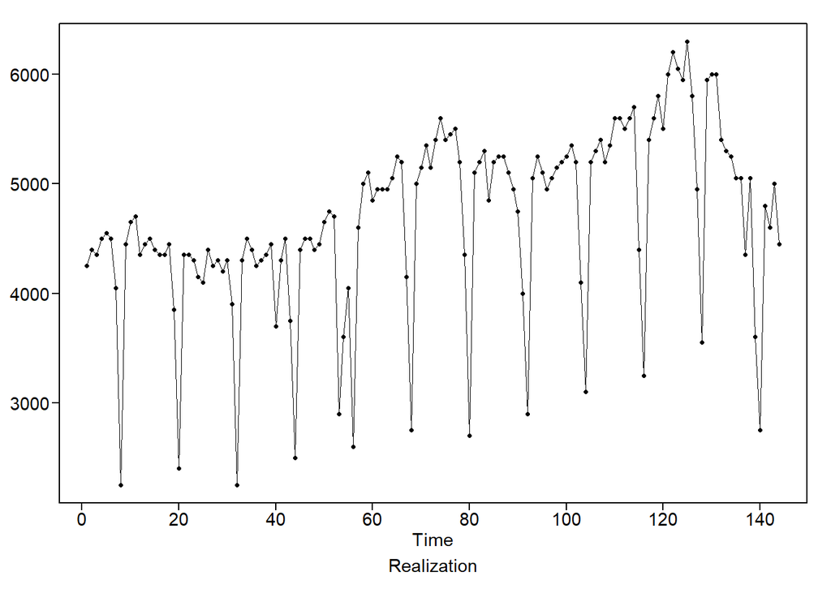

```r
#Visualize the midterm data
plotts.wge(midterm2020)
```

**The Midterm2020 dataset appears to oscillate with some seasonality. The series trends up slightly, then declines during the last unit, which does appear to represent a year. It seems the series cannot be stationary because there is a level of dependency between the mean and time.**

Condition 2 - Subpopulations of $X$ for a given time have a finite and constant variance for all $t$. Restated, the variance does not depend on time.

Condition 3 - The correlation between $Xt_1$ and $Xt_2$ depends only on $t_1-t_2$. That is, the correlation between data points depends only on how far apart they are in time, not where they are in time.

**Based on the first ACF chart (ACF of midterm2020), there appears to be a strong seasonal component represented in the sinusoidal degradation. Autocorrelation cycles are almost identical across similar volumes of lags, evenly spaced.**

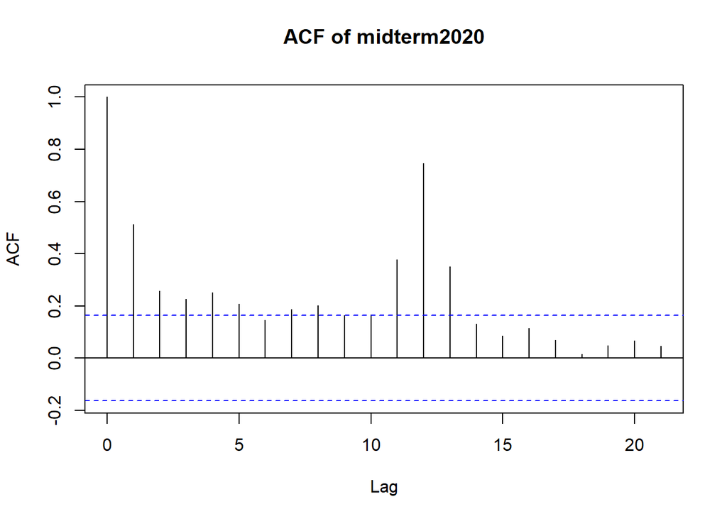

```r
acf(midterm2020, main="ACF of midterm2020")
```

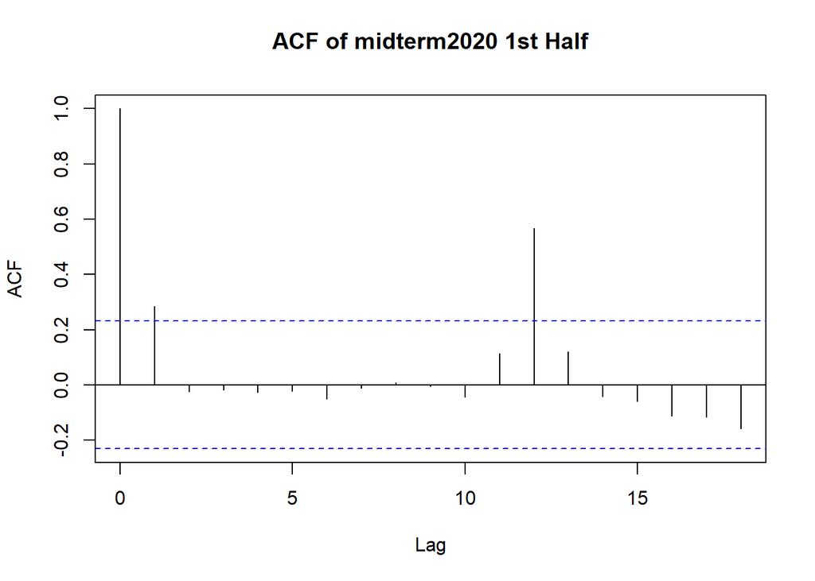

```r
acf(midterm2020[1:72],plot=TRUE, main="ACF of midterm2020 1st Half")
```

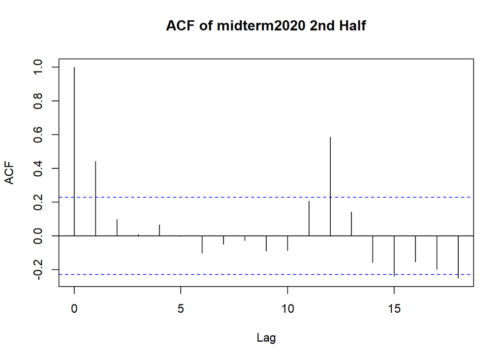

```r
acf(midterm2020[72:144],plot=TRUE, main="ACF of midterm2020 2nd Half")
```

Conclusion

**Because the three conditions of a stationary time series cannot be confirmed, we must conclude that this is not a stationary time series and that there is a dependency on time driving the position of each successive data point.**

### The Models:

#### Consider these two models of the data in the realization in Midterm2020.csv:

- Model 1:
  $$(1-B^{12})( 1-0.5380B-0.0606B^2-0.1923B^3)X_t=a_t$$
- Model 2:
  $$(1-1.0507B+0.0756B^2)X_t=(1-0.5927B-0.2751B^2)a_t$$

#### Questions about Model 1:

2. Write this model in GLP form up to 4 terms.

```r
psi.weights.wge(phi = c(0.5380, 0.0606, 0.1923), lag.max = 4)
```

```
## [1] 0.5380000 0.3500440 0.4132265 0.3469859
```

$$(1-B^{12})Xt=at+0.538a_{t-1}+0.35a_{t-2}+0.413a_{t-3}+0.347a_{t-4}$$

#### Questions about Model 2:

3. Is Model 2 Invertible? Provide evidence for or against.

```r
factor.wge(phi = c(1.0507, -0.0756))
```

```
##
## Coefficients of Original polynomial:
## 1.0507 -0.0756
##
## Factor                 Roots                Abs Recip    System Freq
## 1-0.9730B              1.0277               0.9730       0.0000
## 1-0.0777B              12.8704               0.0777       0.0000
##
##
```

#### Questions for each model:

4. Provide acfs and spectral densities for each model.

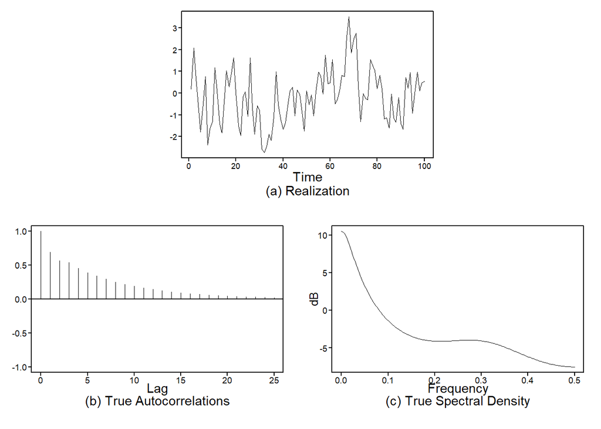

[output not shown]

[output cut: 77 more lines]

```r
#Model 1
#plotts.sample.wge(x = midterm2020, phi = c(0.5380, 0.0606, 0.1923),s=12)
plotts.true.wge(phi = c(0.5380, 0.0606, 0.1923))
```

**Here is the acf and spectral densitie for Model 2.**

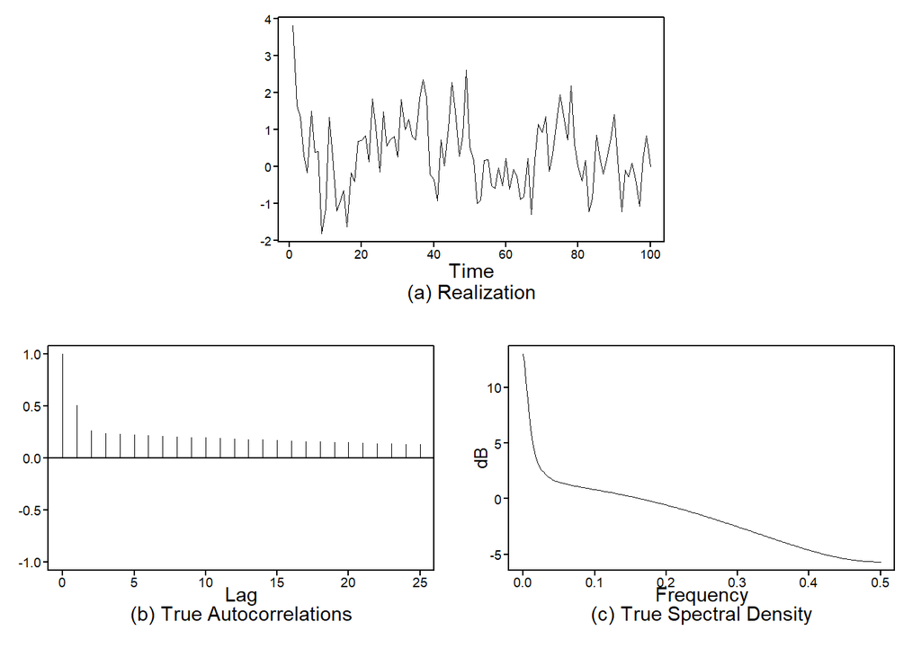

[output not shown]

[output cut: 75 more lines]

```r
#Model 2
plotts.true.wge(phi = c(1.0507,-0.0756), theta = c(0.5927, 0.2751))
```

```r
#Get the length of the dataset
lengthMT2020=length(midterm2020)
#Model 1 Forcast
model1Q6f = fcst(aruma, midterm2020, s = 12, phi = c(0.5380, 0.0606, 0.1923), n.ahead = 12, lastn = T, plot = F)
model1Q6_ase = ase(midterm2020, model1Q6f)
model1Q6_ase = round(model1Q6_ase, digits = 0)

#Model 2 Forcast
model2Q6f = fcst(arma, midterm2020, phi = c(1.0507,-0.0756), theta = c(0.5927,0.2751), n.ahead = 12, lastn = T, plot = F)
model2Q6_ase = ase(midterm2020, model2Q6f)
model2Q6_ase = round(model2Q6_ase, digits = 0)
```

**The ASE for Model 1:**

```r
model1Q6_ase
```

```
## [1] 1301829
```

**The ASE for Model 2:**

```r
model2Q6_ase
```

```
## [1] 836289
```

7. Calculate at least 10 ASEs across the data set and find their average (the rolling window ASE).

```r
#Model 1
phis1 = c(0.5380, 0.0606, 0.1923)
thetas1 = 0
s1  = 12
d1  = 0

trainingSize = 70
horizon = 12
ASEHolder1 = numeric()
dataLength=length(midterm2020)
i=0
for( i in 1:(dataLength-(trainingSize + horizon) + 1))
{

  forecasts1 = fore.aruma.wge(midterm2020[i:(i+(trainingSize-1))],phi = phis1, theta = thetas1, s = s1, d = d1,n.ahead = horizon, plot = F)

  ASE1 = mean((midterm2020[(trainingSize+i):(trainingSize+ i + (horizon) - 1)] - forecasts1$f)^2)

  ASEHolder1[i] = ASE1

}

ASEHolder1
```

```
##  [1]   62151.67   49493.80   51547.38   39834.38   57418.98   63021.43
##  [7]   81029.90   96712.73   90059.87  112142.56   91342.26  103495.29
## [13]   98359.05   91144.05   56163.90   53471.08   39212.14   44274.56
## [19]   36140.13   57318.58   87993.35   91163.85   44907.78   48249.58
## [25]   45475.88   62613.31   52417.91   74309.88   90632.58  105686.83
## [31]   78196.15   42693.73   48163.76   60902.04   58609.89   65562.07
## [37]   79966.91   59950.80   59143.63   73644.86   75917.25   81205.85
## [43]   98479.48  133801.64  101860.29  125121.80  141870.24  163328.35
## [49]  150228.36  117176.41  114385.08  105394.04  186167.90  283486.74
## [55]  363189.07  737157.60  733698.95  958978.04  984575.34 1218370.87
## [61] 1388842.84 1423357.87 1301829.30
```

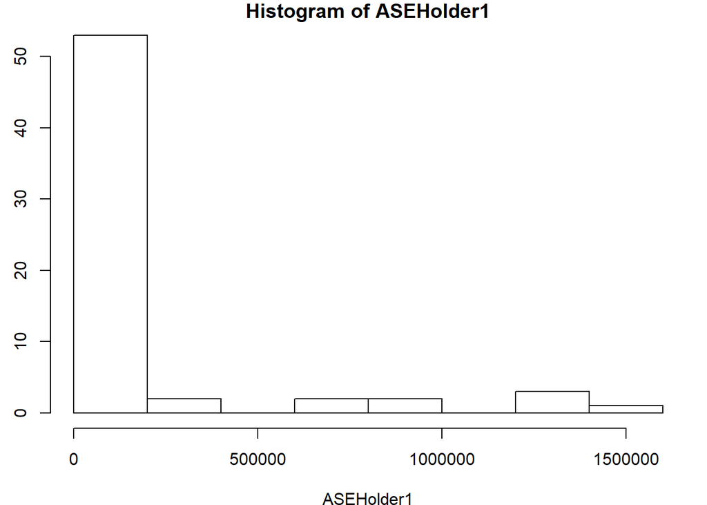

```r
hist(ASEHolder1)
```

```r
summary(ASEHolder1)
```

```
##    Min. 1st Qu.  Median    Mean 3rd Qu.    Max.
##   36140   58014   87993  217350  121149 1423358
```

```r
WindowedASE1 = mean(ASEHolder1)
WindowedASE1
```

```
## [1] 217349.9
```

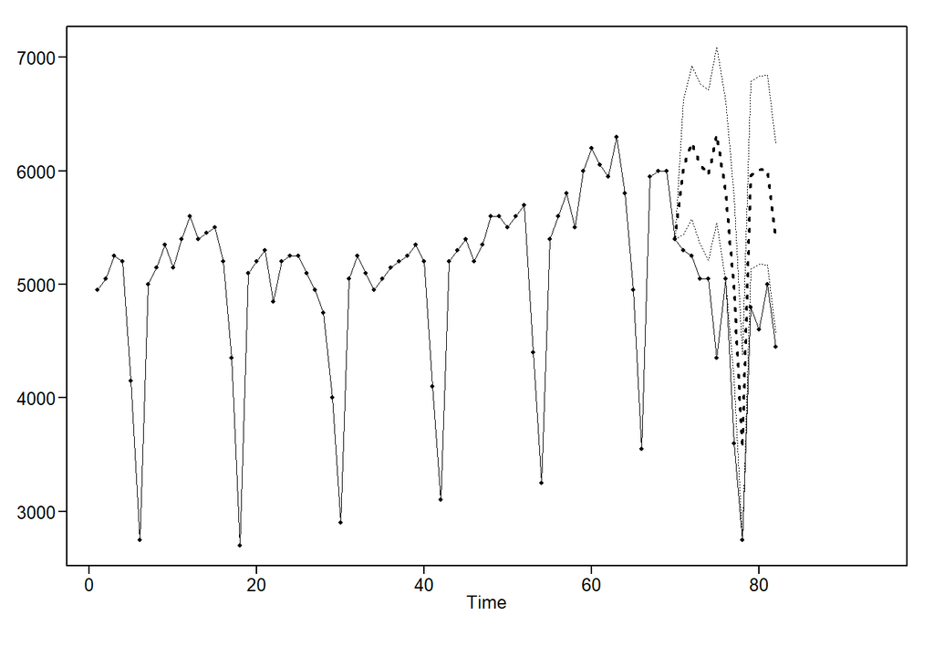

```r
# Visualization

i = length(ASEHolder1)
fs1 = fore.aruma.wge(midterm2020[i:(i+(trainingSize+horizon)-1)],phi = phis1, theta = thetas1, s = s1, d = d1,n.ahead = 12, lastn = T, plot = T)
```

```r
ASE1 = mean((midterm2020[(i+trainingSize):(i+(trainingSize+horizon)-1)] - fs1$f )^2)
```

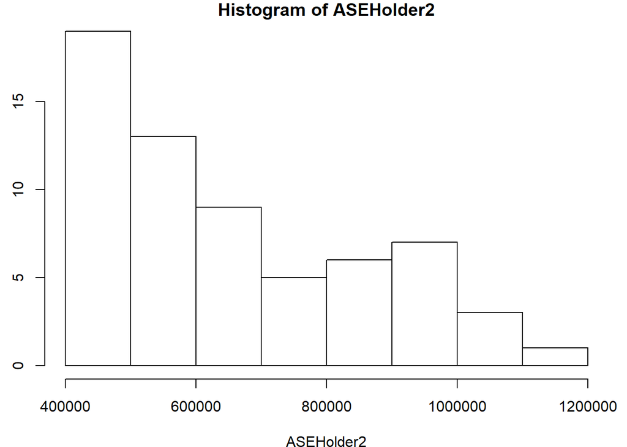

```r
#Model 2
phis2 = c(1.0507,-0.0756)
thetas2 = c(0.5927, 0.2751)

ASEHolder2 = numeric()
i=0
for( i in 1:(dataLength-(trainingSize + horizon) + 1))
{

  forecasts2 = fore.arma.wge(midterm2020[i:(i+(trainingSize-1))],phi = phis2, theta = thetas2,n.ahead = horizon, plot = F)

  ASE2 = mean((midterm2020[(trainingSize+i):(trainingSize+ i + (horizon) - 1)] - forecasts2$f)^2)

  ASEHolder2[i] = ASE2

}

#ASEHolder2 = ASEHolder
hist(ASEHolder2)
```

```r
WindowedASE2 = mean(ASEHolder2)

summary(ASEHolder2)
```

```
##    Min. 1st Qu.  Median    Mean 3rd Qu.    Max.
##  412399  485372  588553  654834  814259 1126142
```

```r
WindowedASE2
```

```
## [1] 654834.2
```

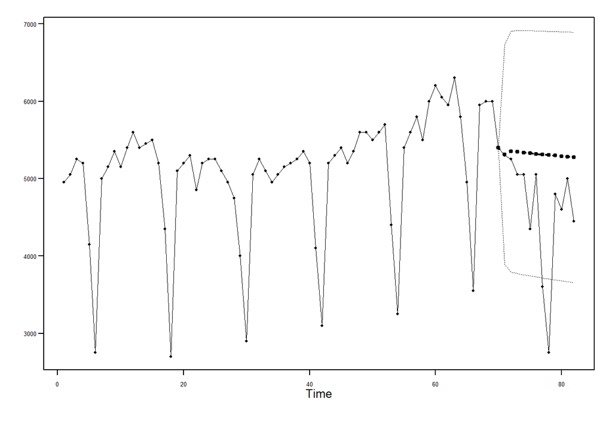

```r
# Visualization

i = length(ASEHolder2)
fs2 = fore.arma.wge(midterm2020[i:(i+(trainingSize+horizon)-1)],phi = phis2, theta = thetas2,n.ahead = 12, lastn = TRUE, plot = T)
```

```r
ASE2 = mean((midterm2020[(i+trainingSize):(i+(trainingSize+horizon)-1)] - fs2$f )^2)
```

8. Compare the single ASE to the rolling window ASE. Are they rougly the same, is one significantly larger? Does it provide evidence as to which model is more useful?

```r
model1Q6_ase
```

```
## [1] 1301829
```

#### Final Question:

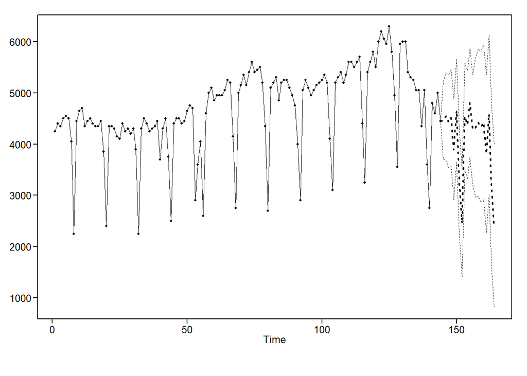

```
## $f
##  [1] 4459.080 4547.715 4438.526 4516.760 3891.012 4653.164 3256.145
##  [8] 2452.694 4542.900 4377.540 4807.565 4283.548 4315.089 4423.155
## [15] 4330.778 4423.553 3810.385 4583.418 3195.813 2400.504
##
## $ll
##  [1] 3704.7287 3691.1213 3542.1564 3567.7356 2906.5531 3646.4537 2231.8385
##  [8] 1415.2154 3495.9383 3323.4963 3748.2204 3220.2713 2964.1342 2991.3776
## [15] 2862.9715 2911.5530 2267.7269 3020.8283 1617.5072  810.3873
##
## $ul
##  [1] 5213.431 5404.309 5334.896 5465.784 4875.471 5659.873 4280.452
##  [8] 3490.173 5589.862 5431.584 5866.909 5346.826 5666.043 5854.933
## [15] 5798.585 5935.554 5353.042 6146.008 4774.118 3990.621
##
```

[output cut: 42 more lines]

```r
#Model 1 Forcast - using tswgewrapped
fcst(type = aruma, x = midterm2020, phi = c(0.5380, 0.0606, 0.1923),s=12, n.ahead = 20)
```

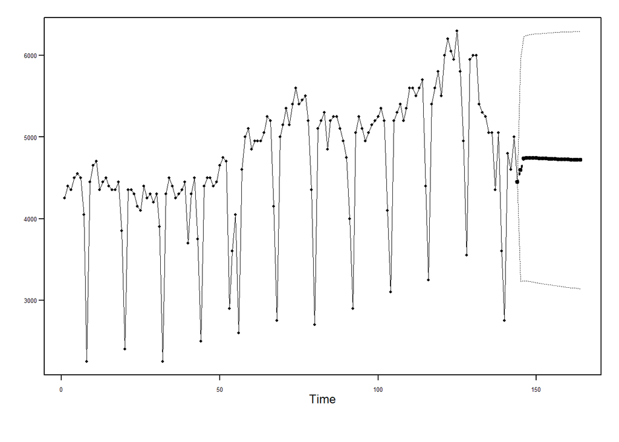

```
## $f
##  [1] 4592.637 4734.368 4743.544 4742.471 4740.649 4738.816 4737.028
##  [8] 4735.288 4733.594 4731.947 4730.344 4728.784 4727.266 4725.790
## [15] 4724.353 4722.955 4721.595 4720.271 4718.983 4717.730
##
## $ll
##  [1] 3232.760 3238.649 3237.330 3229.819 3222.157 3214.833 3207.865
##  [8] 3201.237 3194.931 3188.928 3183.214 3177.772 3172.588 3167.648
## [15] 3162.939 3158.450 3154.169 3150.085 3146.188 3142.469
##
## $ul
##  [1] 5952.515 6230.087 6249.758 6255.122 6259.141 6262.799 6266.191
##  [8] 6269.339 6272.258 6274.965 6277.474 6279.796 6281.945 6283.932
## [15] 6285.767 6287.460 6289.020 6290.457 6291.778 6292.991
##
```

[output cut: 44 more lines]

```r
#Model 2 Forcast - using tswgewrapped
fcst(type = arma, x = midterm2020, phi = c(1.0507,-0.0756), theta = c(0.5927,0.2751), n.ahead = 20)
```

#### BONUS (up to 3 points):

Create an interesting, descriptive and useful plot to visualize the forecasts that the rolling window ASE was based on. This would help the analyst diagnose why the ASE is large or small and/or where it is fitting relatively well and relatively poorly. In addition, it may add confidence to the client that the model is performing adequately.